# 7월 20일 세미나 1

## 1장 요약

1. 컴퓨터 비전의 목표: 한정된 범위에서 임무를 달성하는 인공 시각을 만든다.

   (사람의 인지 능력을 만드는것이 아니다!)
1. 컴퓨터 비전이 어려운 본질적 이유 :

   a. 역문제 : 컴퓨터 비전은 2차원 영상으로 부터 , 3차원 세계를 알아내는 과정이다.하지만, 물체까지 거리와 같은 중요정보가 사라진다.

   b. 불량문제: 답이 유일하지않다. 사람을 영역 분할시 몸통,팔,다리 . 모두 다르게 분할된다.

   c. 광학적 잡음 : 빛 번짐 현상 등
1. 처리과정 :

   a. 전처리 : image processing라 하며, 잡음제거, 초점 흐린 영상 개선 (2장)

   b. 특징추출 ( 저급비전) : 에지, 선분, 원, 코너, 텍스처 특징 추출 (3 ~ 5장)

   c. 해석 (고급 비전): 추출한 특징을 입력받아서, 분류,학습 등 수행 (7장 ~ 12장)
1. 시스템 설계 :

   a. 문제이해

   b. 데이터베이스 수집

   연구를 평가할때는 표준 데이터베이스 사용 여부를 평가 지표로 사용할 수도 있다.

   [pascal voc](http://host.robots.ox.ac.uk/pascal/VOC/voc2012/index.html#data)

   물체의 부류와 위치 영역 분할 데이터베이스

   [버클리 영역분할 데이터베이스](https://www2.eecs.berkeley.edu/Research/Projects/CS/vision/bsds/bench/html/3096-gray.html)

   영역 분할 데이터베이스로, 사람들이 직접 영역 분할한 결과

   c. 알고리즘 설계 구현

   d. 성능평가

### 성능평가

#### 혼동행렬(confusion matrix)

| 참 부류\ 분류결과 | TRUE | FALSE |
| --- | --- | --- |
| TRUE | 1 -> TRUE다 (TP) | 1 -> FALSE다 (FN) |
| FALSE | 0 -> TRUE다 (FP) | 0 -> FALSE다 (TN) |

예를들어, 1과 0을 true false로 분류하는 상황.

1-> TRUE다. 추론이 옳고(TRUE) TRUE로 추정했다,(POSITIVE) : TP

0-> FALSE다. 추론이 옳고(FALSE) FALSE로 추정했다.(NEGATIVE) : TN

#### F-measure

혼동행렬을 바탕으로, 정확률과 재현율을 먼저 계산한다.

$$정확률(precision) = {TP\over(TP+FP)}$$

POSITIVE로 분류한것중, 실제로 추론이 맞는것의 비율.

$$재현률(recall) = {TP\over(TP+FN)}$$

실제 찾아야하는 POSTIVE 중, 실제로 추론이 맞는것의 비율.

$$F1 = {2*precision*recall\over(precision+recall)}$$

우리는 실제로, 이미지에서 TN를 계산할 수 없는 경우가 많다.(틀린 픽셀의 수를 안 구하기 때문.)

F-measure는 TN을 계산하지 않고, 성능을 평가할 수 있다.

###### 기하학적 의미

[figure not shown]

recall과 precision의 조화평균 값으로, 어느하나에 치우치지않는 성능평가를 가능하게한다.

1에 가까우면 좋다!

## 2장요약

## 1. 히스토그램

명암영상에서 히스토그램이란 각 명암값 또는 rgb값이 픽셀에서 몇번 나타나는지 측정.

영상의 특성을 파악하는데 사용한다.

ex) 히스토그램에 봉우리가 명확하면 이진화가 쉽다!

#### 1-1. 명암 영상에서 히스토그램 측정.

cv2.calcHist(images, channels, mask, histSize, ranges[,hist[, accumulate]])

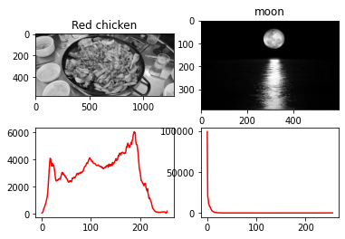

```python
#ex) 명암영상에서 히스토그램

import cv2
from matplotlib import pyplot as plt

img1 = cv2.imread('./data/redchicken.jpg',0)# flag 값으로 0을 붙이면 명암 영상.
img2 = cv2.imread('./data/moon.jpg',0)# flag 값으로 0을 붙이면 명암 영상.

hist1 = cv2.calcHist([img1],[0],None,[256],[0,256])
hist2 = cv2.calcHist([img2],[0],None,[256],[0,256])

plt.subplot(221),plt.imshow(img1,'gray'),plt.title('Red chicken')
plt.subplot(222),plt.imshow(img2,'gray'),plt.title('moon')

plt.subplot(223),plt.plot(hist1,color='r')
plt.subplot(224),plt.plot(hist2,color='r')
plt.show()
#plt.subplot은 위치를 정해준다.

#그림은 이미 이진화가 된것이라, 봉우리를 찾기가 어렵다?
```

#### 1-2. 히스토그램 평활화

히스토그램은 조작을 통해 영상 품질 개선도 한다.

- 개념1 : 정규 히스토그램.

  명암을 전체 픽셀수로 나눔. [명암의 확률값이라 생각하면 된다.]
- 개념2 : 히스토그램 평활화

  히스토그램의 동적범위를 넓혀,

  평평하게 만들고 영상이 선명해진다! (동적범위란, 명암값의 범위를 말함. plot의 x축)

  1) 정규 히스토그램(명암의 이산확률)을 구한다.

  2) 정규 히스토그램의 누적값(명암의 누적확률)을 구한다.

  3) 누적확률x(L-1)의 반올림

cv2.equalizeHist(img)

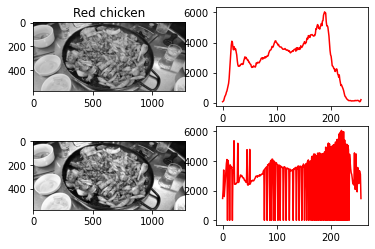

```python
#ex) 히스토그램 평활화
#numpy를 이용한 방법.
import cv2
import numpy as np
from matplotlib import pyplot as plt

img1 = cv2.imread('./data/redchicken.jpg',0)# flag 값으로 0을 붙이면 명암 영상.

hist=cv2.calcHist([img1],[0],None,[256],[0,256])

equalize = cv2.equalizeHist(img1) # opencv의 히스토그램 평활화 함수. grayscale인 경우만 가능하다.
equalize_hist = cv2.calcHist([equalize],[0],None,[256],[0,256])


plt.subplot(221),plt.imshow(img1,'gray'),plt.title('Red chicken')
plt.subplot(222),plt.plot(hist,color='r')

plt.subplot(223),plt.imshow(equalize,'gray')
plt.subplot(224),plt.plot(equalize_hist,color='r')

plt.show()

#결과. 닭고기와 술잔의 경계가 좀더 밝아졌다.
#왜  히스토그램이 평탄화 안되나?
```

#### 1-3. 히스토그램 역투영(backprojection)과 얼굴 검출

히스토그램을 이용한 물체 검출.

히스토그램 역투영을 적용해, 다른 사람의 얼굴을 찾아보자.

명암은 사용안한다. 사람의 얼굴에 같은 명암값이 여럿 있다.

그래서, rgb 공간을 hsi(H:색상,S:채도,I:명암)으로 바꾸고, 명암을 빼서 사용한다.

h와 s 2차원 히스토그램을 그러서 사용한다.

- 개념1. 양자화:

  h와 s축이 수가 너무크면 대부분이 0칸이다.

  그래서, 칸을 축소시키는 방법이다.
- 개념2. 히스토그램 역투영

  원리: 어떤 픽셀의 h와 s 채널값을 알때, 모델의 h^( h,s ) 확률이 높으면, 얼굴의 픽셀일 확률이 높다!

  1) 모델을 양자화 후, 정규 히스토그램으로 만든다.

  2) 모델 h^(h,s)/ 영상 h^(h,s)로 비율히스토그램을 구해 역투영한다.(확률이 높으면 맞다는 뜻.)

cv2.calcBackProject(img, channel, hist, ranges, scale)

```
img: 입력 이미지, [img]처럼 리스트로 감싸서 사용

channel: 처리할 채널, 리스트로 감싸서 사용

hist: 역투영에 사용할 히스토그램

ranges: 각 픽셀이 가질 수 있는 값의 범위

scale: 결과에 적용할 배율 계수
```

얼굴 검출은 효과가 좋지않아서, 머리카락을 검출해보자!

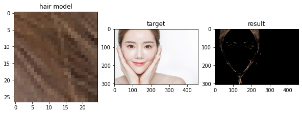

```python
#ex) 히스토그램 역투영 (머리카락 검출)
import cv2
from matplotlib import pyplot as plt

# 모델 이미지 준비, 히스토그램 작성
#model = cv2.imread('./data/face_model.jpg') #얼굴 모델 이미지.
model = cv2.imread('./data/hair_model.jpg')#헤어모델(머리카락 검출)
model_rgb= cv2.cvtColor(model, cv2.COLOR_BGR2RGB)

hsv_model = cv2.cvtColor(model,cv2.COLOR_BGR2HSV) # HSI(HSV) 공간으로 변환.

hsv_model_hist = cv2.calcHist([hsv_model],[0, 1], None,[180, 256], [0, 180, 0, 256])# 모델의 히스토그램에서 i(v)를 빼고 h,s 채널에 대한 히스토그램 계산.
#참조: HSV 이미지에서 값 범위가 0 ~ 179인 H 채널과 값 범위가 0 ~ 255인 S 채널에 대한 히스토그램을 구하기 때문에 M과 I의  shape가 (180, 256)입니다.

#양자화는 calchist에서 수행해준다?


img = cv2.imread('./data/find_face.png') #얼굴을 검출할 사진.
img_rgb = cv2.cvtColor(img, cv2.COLOR_BGR2RGB)
hsv_img = cv2.cvtColor(img,cv2.COLOR_BGR2HSV)# HSI공간으로 변환.
#hsv_img = cv2.calcHist([hsv_img],[0, 1], None,[180, 256], [0, 180, 0, 256])

bp = cv2.calcBackProject([hsv_img], [0, 1], hsv_model_hist,  [0, 180, 0, 256], 1)
result = cv2.bitwise_and(img, img, mask=bp)
result = cv2.cvtColor(result, cv2.COLOR_BGR2RGB)#opencv와 matplot의 rgb 순서가 다르다


plt.figure(figsize=(10,10))
plt.subplot(131),plt.imshow(model_rgb),plt.title('hair model')
plt.subplot(132),plt.imshow(img_rgb),plt.title('target')
plt.subplot(133),plt.imshow(result),plt.title('result')
plt.show()
```

## 2. 이진영상

영상을 흑과 백 두가지 값만 가지는 이진 영상으로 바꿀 필요가 있다!

예를들어, 사진에서 얼굴 위치를 찾을 때 사용한다.

그 순서로는

##### 1. 히스토그램에서 임계값을 찾아서, 구간을 나눠 이진화하기.

##### 2. 이진영상에서 연결요소들을 찾고, 중점을 얼굴 위치로 생각하기.

##### 2-1. 오츄 알고리즘

임계값을 찾아서, 이진화를 수행하는 알고리즘이다!

원리 : 명암영상에서 두 집단간에 최대 분산을 가지는, 임계값 t를 찾는다.

하지만, 이는 global threshold 이므로, 지역특성에 따라 다른 threshold를 적용하는 adaptive thresholding 방법이 있다.

```
임계값  176.0
```

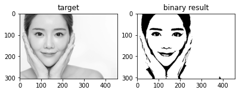

```python
#ex) 오츄 알고리즘으로 사람과 배경 분리. 이진화

img = cv2.imread('./data/find_face.png',0) #사람 사진.
# 오츄 알고리즘은 명암 영상에서만 사용될 수 있다.

t,t_otsu = cv2.threshold(img,0,255,cv2.THRESH_BINARY|cv2.THRESH_OTSU)
print("임계값 ",t)
plt.figure(figsize=(10,10))
t_otsu=cv2.cvtColor(t_otsu, cv2.COLOR_BGR2RGB)
plt.subplot(131),plt.imshow(img,'gray'),plt.title('target')
plt.subplot(132),plt.imshow(t_otsu),plt.title('binary result')
plt.show()
```

###### 2-2. 연결요소 찾는방법

이진영상이 주어졌다면, 범람채움(flood-fill) 알고리즘을 통해 연결요소들을 찾을 수 있다.

알고리즘은 dfs와 bfs를 통해 구현한다.

## 3. 영상처리의 3가지 기본연산

##### 1. 점연산 : 자신의 화소만 보고 새로운 화소 결정.

##### 2. 영역 연산 : 이웃의 화소들을 보고 새로운 값 결정.

##### 3. 기하 연산: 기하학적 규칙에따라 다른 값을 취하기.

#### 3-1. 점연산

지금까지 사용한, 히스토그램 평활화와 오츄 알고리즘은 점연산이라 할 수 있다.

##### 점연산, 선형 점연산 예시(밝게, 어둡게, 반전)

ex) 화소+alpha, 화소-alpha, 최대화소-화소

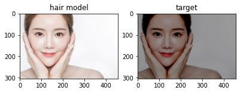

```python
#ex) 점연산. 어둡게
img = cv2.imread('./data/find_face.png') #사람 사진.
dst = cv2.add(img, (-100,-100,-100,0))# 점연산. 컬러사진은. bgr. 마지막 칸 0은 데이터 타입 때문인것으로.

img=cv2.cvtColor(img, cv2.COLOR_BGR2RGB)
dst=cv2.cvtColor(dst, cv2.COLOR_BGR2RGB)
plt.figure(figsize=(10,10))
plt.subplot(131),plt.imshow(img),plt.title('hair model')
plt.subplot(132),plt.imshow(dst),plt.title('target')
plt.show()
```

#### 3-2. 영역연산

##### 상관연산 : 윈도우(filter,mask)와 영상의 곱합(내적).

##### 컨볼루션 : 뒤집은 윈도우와 영상의 곱합.

편의로, 상관연산을 컨볼루션이라 부른다.

윈도우, 필터의 예시 (이미지)

[figure not shown]

컨볼루션연산의 예시로,

박스와 가우시안은 스무딩 연산으로, 영상 개선에 사용한다. 에지를 뭉개는 효과.

샤프닝은 에지를 강조하는 효과.

에지 마스크는 미분연산자 처럼, 값의 변화로 에지를 찾아낸다.

### 3-3. 기하연산

영상을 회전시키거나, 크게하는 작업등에 사용된다.

##### 동차 좌표

$$x = {(y,x,1)}$$

동차좌표를 사용하는 이유는, 3*3인 동차행렬과 행렬곱만 해준다면, 기하연산이 되기 때문이다.

##### 동차행렬들

[figure not shown]

##### 복합 기하변환

예를들어 영상에 K번의 변환이 필요하다면, 미리 기하 연산을 K번 수행한다면 $$A=(이동행렬)*(회전행렬).....K번$$

영상에서는 연산을 한번만 수행해도 된다 $$영상*A$$

영상처리시 k배 만큼 빨라진다고 할 수 있다!

이렇게 직선이 구부러지지 않고 평행으로 유지하는 변환을 affine 변환이라한다.

어파인 변환 Affine Transform : 평행이동 + 회전 + 크기 변환 + 기울임

#### 영상에서 기하 변환 적용

만약 기하변환 결과, 좌표가 (8.6962, 3.0622) 이렇게 float면 어떻게 화소에 매칭할까?

##### - 전방 기하변환

먼저, 기하변환 을 수행한다.

그후, 좌표를 반올림 시켜서, 목표영상으로 변환한다. 이때, 인공적으로 불만족스러운 영상의 현상을 에일리어싱(aliasing)이라 한다.

[figure not shown]

##### - 후방 기하변환

기하변환의 역행렬을 수행한다. 그 후, 반올림 하여 원래 영상의 변환전 좌표의 화소를, 그 좌표에 넣는다.

전방 기하변환의 반대로, 목표영상이 다시 화소를 찾아가는 것. 이러한 에일리어싱 해소방법을 안티 에일리어싱이라 한다.

[figure not shown]

#### 안티 에일리어싱 방법들

후방 기하변환을 수행해도 반올림을 했기에, 여러점이 겹칠 수 밖에 없다.

그래서, 해당 화소값을 예측하는 보간법(interpolation)을 사용한다.

[figure not shown]

비행기 이미지에서, 기하변환 후 화소의 상태이다. 양 3차 보간이 가장 품질이 좋고, 최근접 이웃이 에일리어싱이 가장 심하다.

##### 최근접이웃

가장 가까운 좌표의 화소값을 가지는 방법.

##### 양선형 보간법

주변의 4개점을 이용해 보간하는 방법.

[figure not shown]

#### 3차 보간법

3차함수와 16개의 주변점을 이용해서, 화소값을 보간하는 방법.

## 4. 다해상도

영상의 해상도 M*N을 정수배 또는 실수배로 늘려야 할 수 있다.

## 5. 모폴로지

영상에 나타난 물체의 모양을 분석하거나 원하는 형태로 바꾸는 작업에 사용.

모폴로지는 구조요소(structuring element)와 화소를 연산하여, 모양을 조작한다.

구조요소는 (구조요소_좌표_집합 + 구조요소_데이터)로 2차원 배열로 생각.

#### - 5.1 이진 모폴로지

##### 팽창 연산(dilation)

$$ f[구조요소의 좌표 + 좌표]+구조요소의 데이터 == 1 -> 1$$

한 좌표에서 계산시, 이 중 하나라도 1이면, 화소를 1로만든다.

검은 배경에, 흰색 물체를 키울 때 사용.

##### 침식 연산(erosion)

$$ f[구조요소의 좌표 + 좌표]+구조요소의 데이터 == 0 -> 0 $$

한 좌표에서 계산시, 이 중 하나라도 0이면, 화소를 0로만든다.

검은 배경에, 흰색 물체를 작게 만들때 사용.

##### 열기 (opening)

$$(f ⊝ s) ⊕ s$$

팽창( 침식(f,s), s) 로 생각.

침식 연산 후, 나머지 부분은 원래 크기로 돌리기. (흰 노이즈 제거)

##### 닫기 (closing)

$$(f ⊕ s) ⊝ s $$

침식( 팽창(f,s), s) 로 생각.

팽창 연산 후, 나머지 부분은 원래 크기로 돌리기. (검은 노이즈 제거)

#### - 5.2 명암 모폴로지

이진 모폴로지와 달리, 1과 0 대신 명암값을 가진다.

구조요소를 설계하는것이 어려워, 평편한 구조요소만을 사용해 연산을 수행한다.

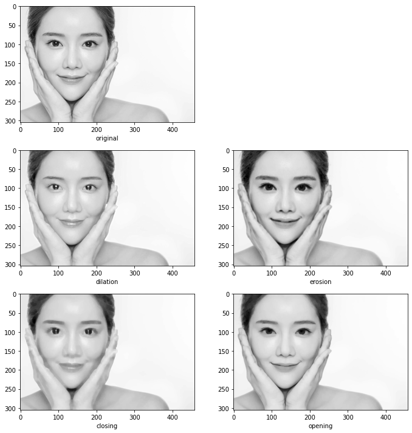

```python
#ex) 명암 모폴로지 연산

#커널(구조요쇼)은 사각형 모양으로 생성.
ker_small = np.ones([3,3])
ker_big = np.ones([5,5])

#opencv에서는 설명과 달리, 커널의 값이 0이 아니면 연산을 하는것으로 취급한다. 그래서, np.ones로 생성.

img = cv2.imread('./data/find_face.png',0)
#img = cv2.cvtColor(img, cv2.COLOR_BGR2RGB)

fig =plt.figure(figsize=(10,10))
plt.subplot(321)
plt.imshow(img,'gray')
plt.xlabel('original')

plt.subplot(323)
plt.imshow(cv2.dilate(img,ker_small),'gray')
plt.xlabel('dilation')

plt.subplot(324)
plt.imshow(cv2.erode(img,ker_small),'gray')
plt.xlabel('erosion')

plt.subplot(325)
plt.imshow(cv2.morphologyEx(img, cv2.MORPH_CLOSE, ker_big),'gray')
plt.xlabel('closing')

plt.subplot(326)
plt.imshow(cv2.morphologyEx(img, cv2.MORPH_OPEN, ker_big),'gray')
plt.xlabel('opening')

fig.tight_layout()
plt.show()


# 팽창은 흰 눈동자를 크게 만든다.
# 침식은 흰 눈동자를 작게 만든다..
```